# Exercise 6.9

Kári Hlynsson

2024-02-12

In this exercise, we will predict the number of applications received using the other variables in the `College` data set.

## Part (a)

Split the data into a training set and a test set.

```r
library(ISLR2)
data(College)

set.seed(1)

rownames(College) <- NULL # clutter

n <- nrow(College)
s <- sample(c(TRUE, FALSE), n, replace = T, prob = c(0.75, 0.25))

# for lm
train <- College[s, ]
test  <- College[!s, ]

# for glmnet
train.X <- model.matrix(Apps ~ ., train)[,-1]
train.Y <- train$Apps

test.X <- model.matrix(Apps ~ ., test)[,-1]
test.Y <- test$Apps
```

## Part (b)

Fit a linear model using least squares on the training set, and report the test error obtained.

```r
lm.fit <- lm(Apps ~ ., data = train)
summary(lm.fit)
```

```
##
## Call:
## lm(formula = Apps ~ ., data = train)
##
## Residuals:
##     Min      1Q  Median      3Q     Max
## -3163.8  -395.6   -58.8   286.3  7046.8
##
## Coefficients:
##               Estimate Std. Error t value Pr(>|t|)
## (Intercept) -5.750e+02  4.323e+02  -1.330 0.183984
## PrivateYes  -5.814e+02  1.505e+02  -3.863 0.000125 ***
## Accept       1.271e+00  5.608e-02  22.666  < 2e-16 ***
## Enroll      -2.364e-01  2.038e-01  -1.160 0.246516
## Top10perc    4.438e+01  6.165e+00   7.199 1.93e-12 ***
## Top25perc   -1.331e+01  4.728e+00  -2.815 0.005043 **
## F.Undergrad  7.160e-02  3.526e-02   2.030 0.042783 *
## P.Undergrad -1.971e-03  3.996e-02  -0.049 0.960681
## Outstate    -3.327e-02  2.058e-02  -1.617 0.106435
## Room.Board   1.355e-01  5.177e-02   2.618 0.009071 **
## Books        2.406e-02  2.530e-01   0.095 0.924254
## Personal     2.136e-02  6.674e-02   0.320 0.749095
## PhD         -8.266e+00  4.968e+00  -1.664 0.096692 .
## Terminal    -7.216e-01  5.445e+00  -0.133 0.894616
## S.F.Ratio    8.134e+00  1.380e+01   0.589 0.555806
## perc.alumni -6.668e+00  4.414e+00  -1.511 0.131389
## Expend       7.162e-02  1.338e-02   5.354 1.25e-07 ***
## Grad.Rate    8.954e+00  3.158e+00   2.835 0.004742 **
## ---
## Signif. codes:  0 '***' 0.001 '**' 0.01 '*' 0.05 '.' 0.1 ' ' 1
##
## Residual standard error: 960.1 on 567 degrees of freedom
## Multiple R-squared:  0.9282, Adjusted R-squared:  0.926
## F-statistic: 431.1 on 17 and 567 DF,  p-value: < 2.2e-16
```

Test error:

```r
lm.pred <- predict(lm.fit, test)
mean((test.Y - lm.pred)^2)
```

```
## [1] 1962820
```

## Part (c)

Fit a ridge regression model on the training set, with $\lambda$ chosen by cross-validation. Report the test error obtained.

```r
library(glmnet)
```

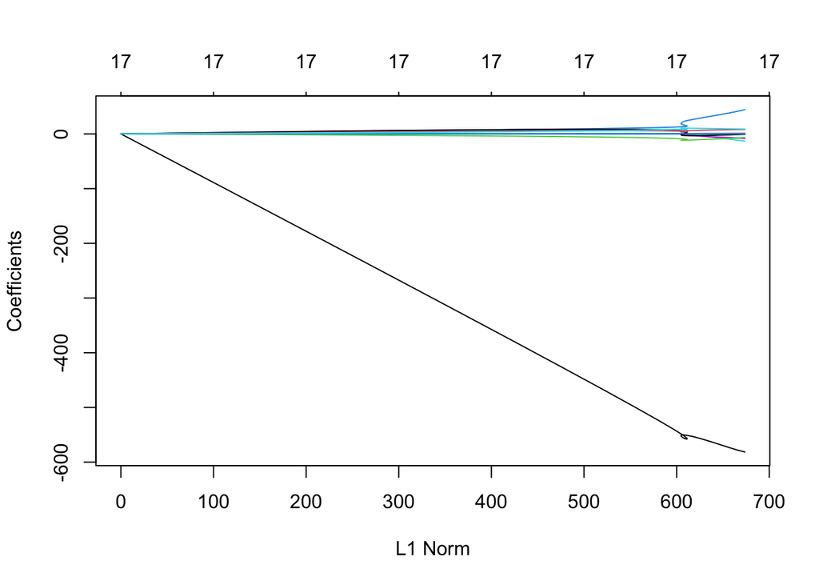

```r
# grid for the lambdas (glmnet)
grid <- 10^seq(10, -2, length = 100)

ridge.fit <- glmnet(train.X, train.Y, alpha = 0, lambda = grid, thresh = 1e-12)
plot(ridge.fit)
```

Cross validate to select best value of $\lambda$:

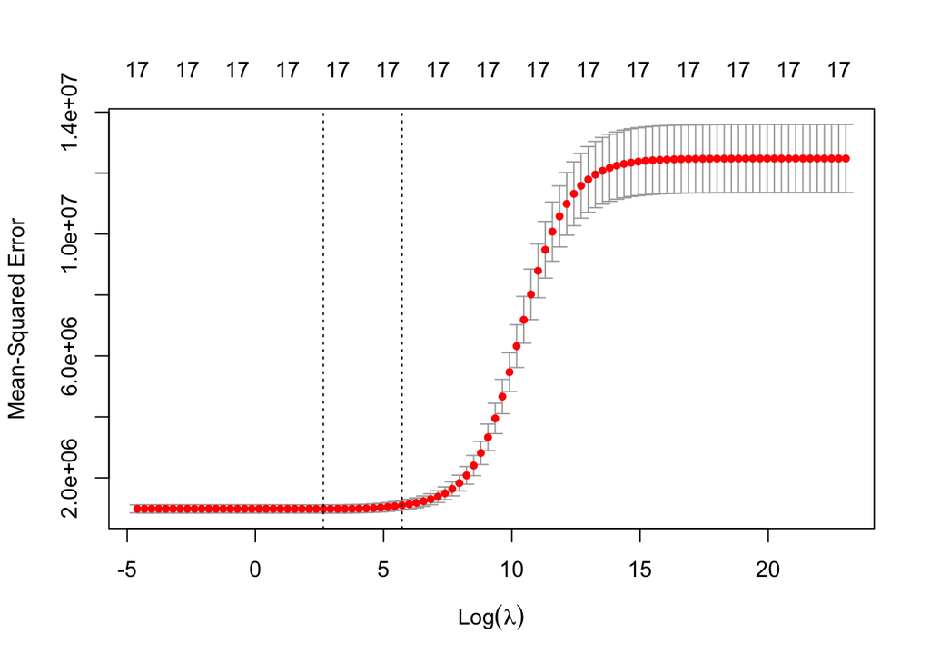

```r
cv.out.ridge <- cv.glmnet(train.X, train.Y, alpha = 0, lambda = grid, thresh = 1e-12)
plot(cv.out.ridge)
```

Best value is

```r
lambda.ridge <- cv.out.ridge$lambda.min
lambda.ridge
```

```
## [1] 14.17474
```

```r
ridge.pred <- predict(ridge.fit, s = lambda.ridge, newx = test.X)
mean((test.Y - ridge.pred)^2)
```

```
## [1] 2085872
```

Similar to OLS. Coefs:

```r
predict(ridge.fit, s = lambda.ridge, type = "coefficient")
```

```
## 18 x 1 sparse Matrix of class "dgCMatrix"
##                        s1
## (Intercept) -665.27472808
## PrivateYes  -578.82036655
## Accept         1.21615078
## Enroll        -0.09344128
## Top10perc     42.04238578
## Top25perc    -11.89190883
## F.Undergrad    0.07045504
## P.Undergrad   -0.00381861
## Outstate      -0.02931770
## Room.Board     0.14154830
## Books          0.02851039
## Personal       0.01483614
## PhD           -7.68749405
## Terminal      -1.12160640
## S.F.Ratio      7.97098767
## perc.alumni   -7.30063609
## Expend         0.07275585
## Grad.Rate      9.15396634
```

## Part (d)

Fit a ridge lasso model on the training set, with $\lambda$ chosen by cross-validation. Report the test error obtained, along with the number of non-zero coefficient estimates.

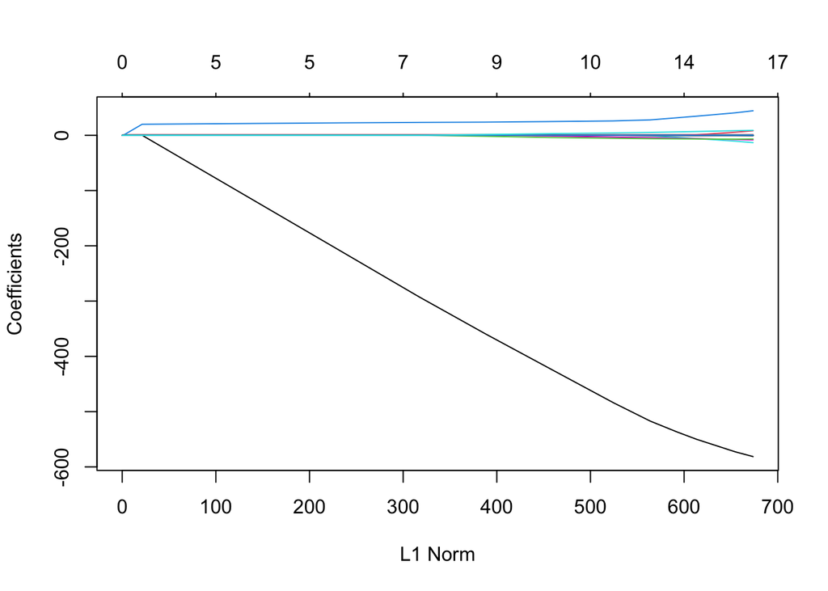

```r
lasso.fit <- glmnet(train.X, train.Y, alpha = 1, lambda = grid, thresh = 1e-12)
plot(lasso.fit)
```

Find best $\lambda$:

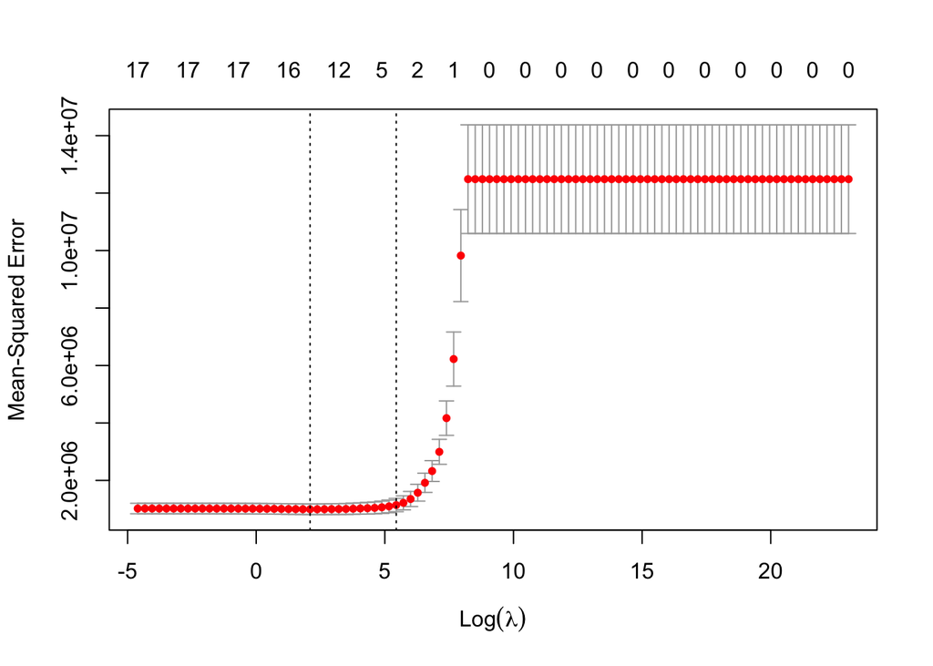

```r
cv.out.lasso <- cv.glmnet(train.X, train.Y, alpha = 1, lambda = grid, thresh = 1e-12)
plot(cv.out.lasso)
```

Optimal $\lambda$:

```r
lambda.lasso <- cv.out.lasso$lambda.min
lambda.lasso
```

```
## [1] 8.111308
```

Fit the model:

```r
lasso.pred <- predict(lasso.fit, s = lambda.lasso, test.X)
mean((test.Y - lasso.pred)^2)
```

```
## [1] 2077743
```

Coefficients:

```r
predict(lasso.fit, s = lambda.lasso, type = "coefficient")
```

```
## 18 x 1 sparse Matrix of class "dgCMatrix"
##                        s1
## (Intercept) -6.270158e+02
## PrivateYes  -5.645112e+02
## Accept       1.227621e+00
## Enroll       .
## Top10perc    3.844565e+01
## Top25perc   -8.966791e+00
## F.Undergrad  4.661831e-02
## P.Undergrad  .
## Outstate    -2.359102e-02
## Room.Board   1.223831e-01
## Books        5.695071e-05
## Personal     1.164391e-02
## PhD         -7.080744e+00
## Terminal    -5.777081e-01
## S.F.Ratio    3.891540e+00
## perc.alumni -6.900887e+00
## Expend       6.934975e-02
## Grad.Rate    7.806744e+00
```

15 non-zero components. Similar performance to other models.

## Part (e)

Fit a PCR model on the training set, with $M$ chosen by cross-validation. Report the test error obtained, along with the value of $M$ selected by cross-validation.

```r
library(pls)
pcr.fit <- pcr(Apps ~ ., data = train, scale = TRUE, validation = "CV")
summary(pcr.fit)
```

```
## Data:    X dimension: 585 17
##  Y dimension: 585 1
## Fit method: svdpc
## Number of components considered: 17
##
## VALIDATION: RMSEP
## Cross-validated using 10 random segments.
##        (Intercept)  1 comps  2 comps  3 comps  4 comps  5 comps  6 comps  7 comps  8 comps  9 comps  10 comps  11 comps  12 comps  13 comps
## CV            3533     3467     1665     1676     1417     1250     1238     1227     1229     1148      1144      1147      1146      1143
## adjCV         3533     3468     1663     1681     1400     1243     1235     1227     1238     1145      1142      1145      1144      1141
##        14 comps  15 comps  16 comps  17 comps
## CV         1143      1146      1021      1011
## adjCV      1141      1144      1018      1007
##
## TRAINING: % variance explained
##       1 comps  2 comps  3 comps  4 comps  5 comps  6 comps  7 comps  8 comps  9 comps  10 comps  11 comps  12 comps  13 comps  14 comps  15 comps
## X      31.562    57.48    64.79    70.68    76.11    80.93    84.61    87.78    90.82     93.19     95.31     97.04     98.11     98.94     99.45
## Apps    4.295    78.09    78.19    85.10    88.19    88.21    88.44    88.52    89.92     90.08     90.08     90.13     90.20     90.22     90.27
##       16 comps  17 comps
## X        99.82    100.00
## Apps     92.48     92.82
```

Cool plot:

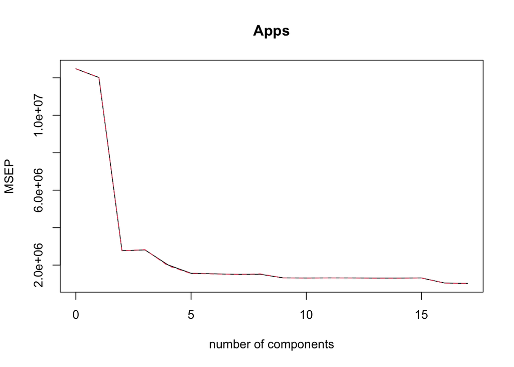

```r
validationplot(pcr.fit, val.type = "MSEP")
```

The CV error is lowest for 17 components, which is essentially least squares. Let’s use that.

```r
pcr.pred <- predict(pcr.fit, ncomp = 17, test.X)
mean((test.Y - pcr.pred)^2)
```

```
## [1] 1962820
```

Similar performance.

## Part (f)

Fit a PLS model on the training set, with $M$ chosen by cross-validation. Report the test error obtained, along with the value of $M$ selected by cross-validation.

```r
pls.fit <- plsr(Apps ~ ., data = train, scale = TRUE, validation = "CV")
summary(pls.fit)
```

```
## Data:    X dimension: 585 17
##  Y dimension: 585 1
## Fit method: kernelpls
## Number of components considered: 17
##
## VALIDATION: RMSEP
## Cross-validated using 10 random segments.
##        (Intercept)  1 comps  2 comps  3 comps  4 comps  5 comps  6 comps  7 comps  8 comps  9 comps  10 comps  11 comps  12 comps  13 comps
## CV            3533     1514     1258     1131     1096     1046     1015     1005    999.6    999.4     999.5     999.4     998.3     997.8
## adjCV         3533     1511     1261     1128     1092     1040     1012     1002    996.9    996.6     996.6     996.3     995.4     994.9
##        14 comps  15 comps  16 comps  17 comps
## CV        998.0     998.0     998.1     998.1
## adjCV     995.1     995.1     995.2     995.2
##
## TRAINING: % variance explained
##       1 comps  2 comps  3 comps  4 comps  5 comps  6 comps  7 comps  8 comps  9 comps  10 comps  11 comps  12 comps  13 comps  14 comps  15 comps
## X       26.23    43.59    63.00    66.33    70.33    73.91    78.66    81.53    83.99     86.22     88.65     91.56     93.30     94.95     97.15
## Apps    82.39    87.84    90.34    91.21    91.98    92.61    92.71    92.76    92.78     92.80     92.81     92.82     92.82     92.82     92.82
##       16 comps  17 comps
## X        98.11    100.00
## Apps     92.82     92.82
```

Cool plot time:

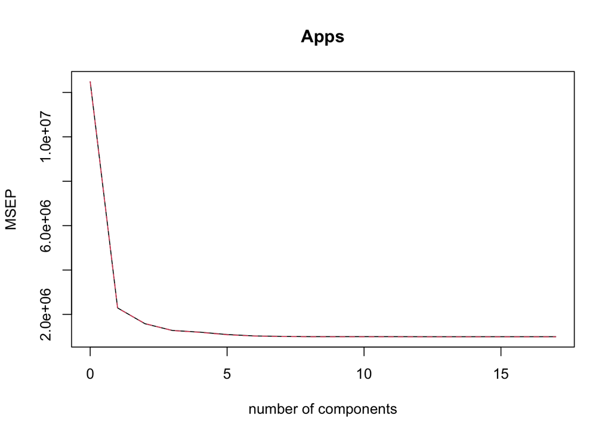

```r
validationplot(pls.fit, val.type = "MSEP")
```

```r
pls.pred <- predict(pls.fit, ncomp = 8, test.X)
mean((test.Y - pls.pred)^2)
```

```
## [1] 2016594
```

Similar performance…

## Part (g)

Comment on the results obtained. How accurately can we predict the number of college applications received? Is there much difference among the test errors resulting from these five approaches?

We will use the formula for $R^2$:

$$R^2 = 1 - \frac{\mathrm{RSS}}{\mathrm{TSS}} = 1 - \frac{\sum_{i = 1}^n
(y_i - \hat y_i)^2}{\sum_{i = 1}^n (y_i - \overline y)}.$$

Tally ho:

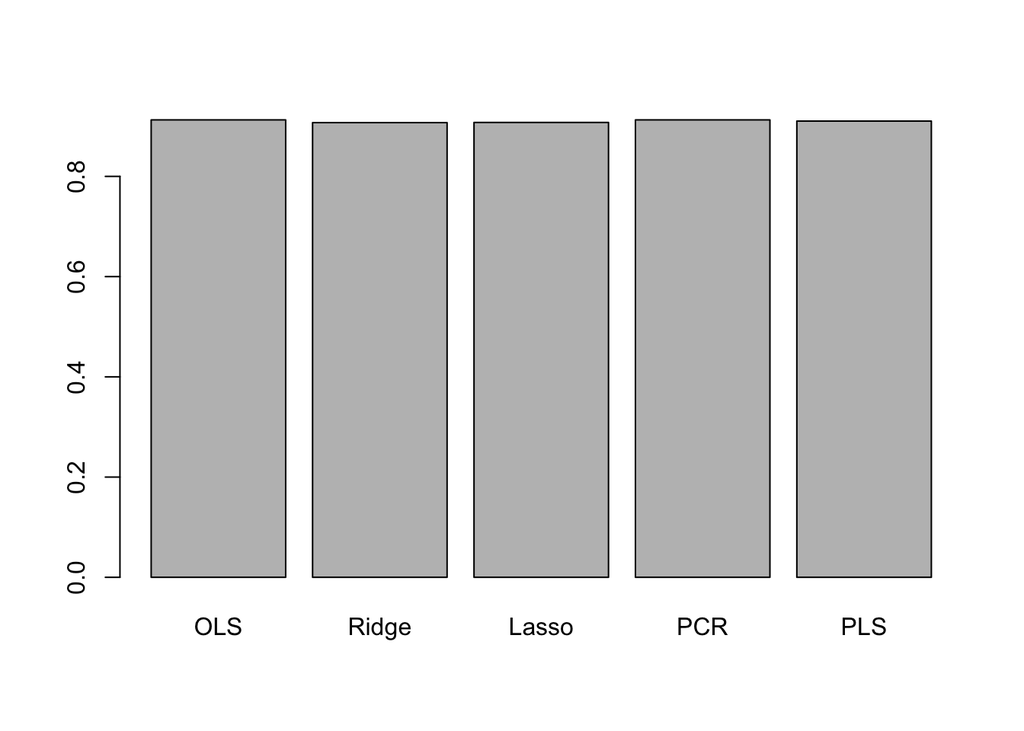

```r
tss   <- sum((test.Y - mean(test.Y))^2)
preds <- list(lm.pred, ridge.pred, lasso.pred, pcr.pred, pls.pred)
rsss  <- lapply(preds, function(v) sum((v - test.Y)^2))
rsqs  <- sapply(rsss, function(rss) 1 - rss/tss)
names <- c("OLS", "Ridge", "Lasso", "PCR", "PLS")

barplot(rsqs, names.arg = names)
```

Differences are barely noticable. However notice that OLS and PCR have the same $R^2$ which is not surprising since we used 17 components for PCR which is equivalent to performing OLS. PLS did the best job of dimensionality reduction, with 8 dimensions, followed by lasso with 15.